# Coursera Practical Machine Learning Course Project

Duc Nguyen

# Loading the data and library

```r
# Loading Library
library(caret)
# loading the data
training <- read.csv("pml-training.csv", header = T, na.strings = c("NA", "", "#DIV0/!")) # add NA to the blank space
testing <- read.csv("pml-testing.csv", header = T, na.strings = c("NA", "", "#DIV0/!"))

dim(training)
```

```
## [1] 19622   160
```

```r
dim(testing)
```

```
## [1]  20 160
```

```r
summary(training$classe)
```

```
##    A    B    C    D    E
## 5580 3797 3422 3216 3607
```

```r
unique(training$user_name)
```

```
## [1] carlitos pedro    adelmo   charles  eurico   jeremy
## Levels: adelmo carlitos charles eurico jeremy pedro
```

```r
summary(training$user_name)
```

```
##   adelmo carlitos  charles   eurico   jeremy    pedro
##     3892     3112     3536     3070     3402     2610
```

# Cleaning the Data

## Removing the missing values

I first remove the columns which contains any missing values to use only the columns which is completed.

```r
# Removing the first columns which is the index
training <- training[, -1]
testing <- testing[, -1]
dim(training)
```

```
## [1] 19622   159
```

```r
# Remove the columns with missing values
training1 <- training[, colSums(is.na(training)) == 0]
dim(training1)
```

```
## [1] 19622    59
```

```r
testing1 <- testing[, colSums(is.na(testing)) == 0]
dim(testing1)
```

```
## [1] 20 59
```

```r
# Checking the remaining variables
str(training1)
```

```
## 'data.frame':    19622 obs. of  59 variables:
##  $ user_name           : Factor w/ 6 levels "adelmo","carlitos",..: 2 2 2 2 2 2 2 2 2 2 ...
##  $ raw_timestamp_part_1: int  1323084231 1323084231 1323084231 1323084232 1323084232 1323084232 1323084232 1323084232 1323084232 1323084232 ...
##  $ raw_timestamp_part_2: int  788290 808298 820366 120339 196328 304277 368296 440390 484323 484434 ...
##  $ cvtd_timestamp      : Factor w/ 20 levels "2/12/2011 13:32",..: 15 15 15 15 15 15 15 15 15 15 ...
##  $ new_window          : Factor w/ 2 levels "no","yes": 1 1 1 1 1 1 1 1 1 1 ...
##  $ num_window          : int  11 11 11 12 12 12 12 12 12 12 ...
##  $ roll_belt           : num  1.41 1.41 1.42 1.48 1.48 1.45 1.42 1.42 1.43 1.45 ...
##  $ pitch_belt          : num  8.07 8.07 8.07 8.05 8.07 8.06 8.09 8.13 8.16 8.17 ...
##  $ yaw_belt            : num  -94.4 -94.4 -94.4 -94.4 -94.4 -94.4 -94.4 -94.4 -94.4 -94.4 ...
##  $ total_accel_belt    : int  3 3 3 3 3 3 3 3 3 3 ...
##  $ gyros_belt_x        : num  0 0.02 0 0.02 0.02 0.02 0.02 0.02 0.02 0.03 ...
##  $ gyros_belt_y        : num  0 0 0 0 0.02 0 0 0 0 0 ...
##  $ gyros_belt_z        : num  -0.02 -0.02 -0.02 -0.03 -0.02 -0.02 -0.02 -0.02 -0.02 0 ...
##  $ accel_belt_x        : int  -21 -22 -20 -22 -21 -21 -22 -22 -20 -21 ...
```

[output cut: 45 more lines]

## Removing the near zero values

There are still many columns which contains very small values in comparision with others. We also need to exclude these variables in the regression models.

```r
nzv <- nearZeroVar(training1, saveMetrics = T)
str(nzv)
```

```
## 'data.frame':    59 obs. of  4 variables:
##  $ freqRatio    : num  1.1 1 1 1 47.3 ...
##  $ percentUnique: num  0.0306 4.2656 85.5315 0.1019 0.0102 ...
##  $ zeroVar      : logi  FALSE FALSE FALSE FALSE FALSE FALSE ...
##  $ nzv          : logi  FALSE FALSE FALSE FALSE TRUE FALSE ...
```

```r
training2 <- training1[, nzv$nzv == F] # Keep only the Non-near zero variables

nzv2 <- nearZeroVar(testing1, saveMetrics = T)
testing2 <- testing1[, nzv2$nzv == F] # Keep only the Non-near zero variables
dim(testing2)
```

```
## [1] 20 58
```

```r
dim(training2)
```

```
## [1] 19622    58
```

# Data splitting

To do Machine Learning and test the model, I split the data into training (70%) and the test (30%) set.

```r
set.seed(3456)
inTrain <- createDataPartition(training2$classe, p = .7, list = F)
myTrain <- training2[inTrain, ]
myTest <-  training2[-inTrain, ]
```

# Machine Learning: Prediction Algorithims

Here I am going to use 3 techniques which has been shown in the class. It includes “Prediction with Decision Trees”, “Prediction with Random forests”, and “Prediction with Generalized Boosted Regression”

## Prediction with Decission Trees

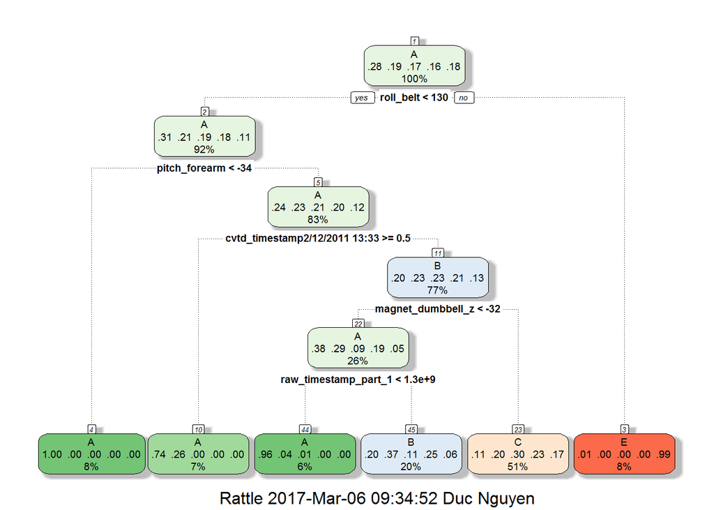

```r
set.seed(123456)
library(rattle)
library(rpart)
mod_tree <- train(classe~., method = "rpart", data = myTrain)
pred_tree <- predict(mod_tree, newdata = myTest)
#print(mod_tree$finalModel)
fancyRpartPlot(mod_tree$finalModel)
```

```r
# Accuracy of the model
(Accuracy_tree <- confusionMatrix(pred_tree, myTest$classe)$overall["Accuracy"])
```

```
##  Accuracy
## 0.4898895
```

## Prediction with Random Forests

```r
set.seed(123456)
library(randomForest)

mod_rf <- randomForest(classe~., data = myTrain)
pred_rf <- predict(mod_rf, myTest)
(method_rf <- confusionMatrix(pred_rf, myTest$classe))
```

```
## Confusion Matrix and Statistics
##
##           Reference
## Prediction    A    B    C    D    E
##          A 1674    0    0    0    0
##          B    0 1139    0    0    0
##          C    0    0 1026    1    0
##          D    0    0    0  963    0
##          E    0    0    0    0 1082
##
## Overall Statistics
##
##                Accuracy : 0.9998
##                  95% CI : (0.9991, 1)
##     No Information Rate : 0.2845
##     P-Value [Acc > NIR] : < 2.2e-16
##
##                   Kappa : 0.9998
##  Mcnemar's Test P-Value : NA
##
## Statistics by Class:
##
##                      Class: A Class: B Class: C Class: D Class: E
## Sensitivity            1.0000   1.0000   1.0000   0.9990   1.0000
## Specificity            1.0000   1.0000   0.9998   1.0000   1.0000
## Pos Pred Value         1.0000   1.0000   0.9990   1.0000   1.0000
## Neg Pred Value         1.0000   1.0000   1.0000   0.9998   1.0000
## Prevalence             0.2845   0.1935   0.1743   0.1638   0.1839
## Detection Rate         0.2845   0.1935   0.1743   0.1636   0.1839
## Detection Prevalence   0.2845   0.1935   0.1745   0.1636   0.1839
## Balanced Accuracy      1.0000   1.0000   0.9999   0.9995   1.0000
```

```r
# Accuracy of the method
method_rf$overall["Accuracy"]
```

```
##  Accuracy
## 0.9998301
```

```r
mod_rf
```

```
##
## Call:
##  randomForest(formula = classe ~ ., data = myTrain)
##                Type of random forest: classification
##                      Number of trees: 500
## No. of variables tried at each split: 7
##
##         OOB estimate of  error rate: 0.09%
## Confusion matrix:
##      A    B    C    D    E  class.error
## A 3906    0    0    0    0 0.0000000000
## B    2 2656    0    0    0 0.0007524454
## C    0    5 2389    2    0 0.0029215359
## D    0    0    1 2250    1 0.0008880995
## E    0    0    0    2 2523 0.0007920792
```

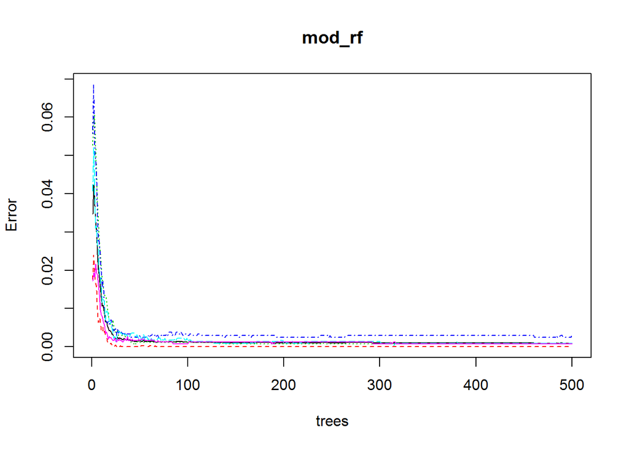

```r
# Plotting the fit
plot(mod_rf)
```